# Monitorización nivel de “salud” de una red corporativa de PC’s

Juan Carlos, Fco.Javier Motos, Alonso Flores y David Martín

Junio 2017

##### Objetivo de la práctica

La práctica consiste en obtener el nivel de salud del parque de PCs en una empresa en función de las vulnerabilidades que tienen.

##### Condiciones:

Teniendo en cuenta que el CVSS se basa en la combinación de tres métricas, la presente práctica parte del valor BASE asignado a cada vulnerabilidad en su publicación. Este valor se ve modificado por factores TEMPORALES y de ENTORNO. En nuestro caso solo hemos considerado 2 de ellos: el base y el de entorno.

### Preguntas a responder

#### ÁMBITO PC’s

- Distribución % equipos por nº vulnerabilidades
- Distribución % por nivel de criticidad
- Salud del parque global

#### El flujo planteado es:

- Obtener el software instalado de las máquinas de la empresa (se identifican: Nombre del programa y Versión)
- Obtención del listado de CPEs oficiales de dichos programas
- Se realiza un matching entre CPEs y listado de software por cada máquina.
- Obtenemos un listado de CVEs actualizados
- Se realiza un matching entre CVE y los CPE encontrados en el listado de software de cada máquina
- Se establece un sistema de scoring de vulnerabilidades basado en el CVSS y se asigna un valor de “salud” por cada máquina.
- Se visualizar los resultados desde diferentes perspectivas

#### NOTA: Para garantizar la presentación de resultados se ha desarrollado un módulo específico para la creación de un entorno simulado partiendo de las siguientes condiciones:

- Fichero con el listado de los programas comprados por la empresa
- Fichero con los PC’s instalados en la empresa y su criticidad
- Creación de un fichero de vulnerabilidades por software (número aleatorio de vulnerabilidades y también severidad aleatoria)
- Creación de un entorno ficción en el que cada pc tiene un número aleatorio de programas instalados, a partir del cual se genera el fichero final con la relación de software y vulnerabilidades instaladas por pc en la compañía

#### *Fuente de datos*

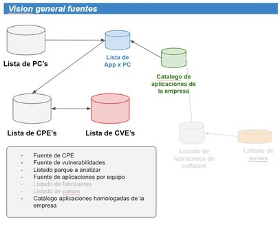

Fuente de datos

#### *Algoritmo y funciones*

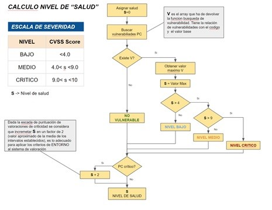

Algoritmo y funciones

# **Resultados**

## *Gráfico 1*

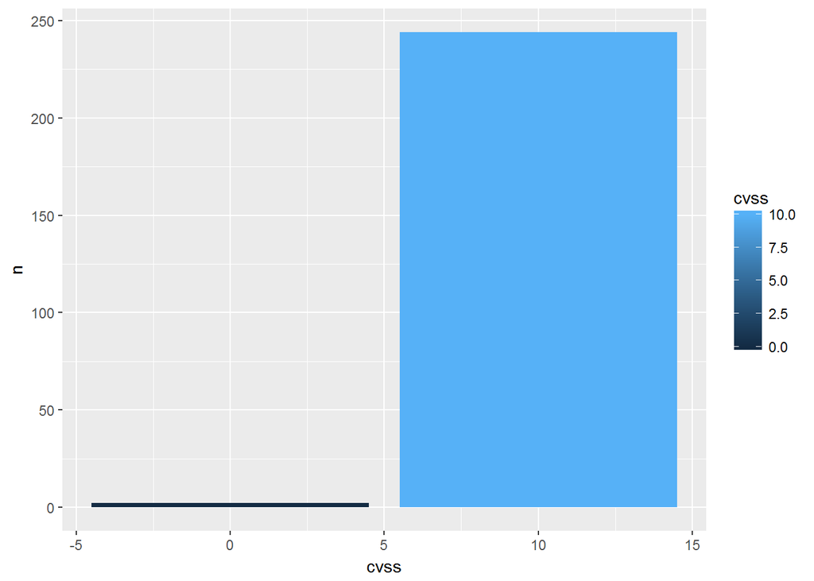

## *Gráfico 2*

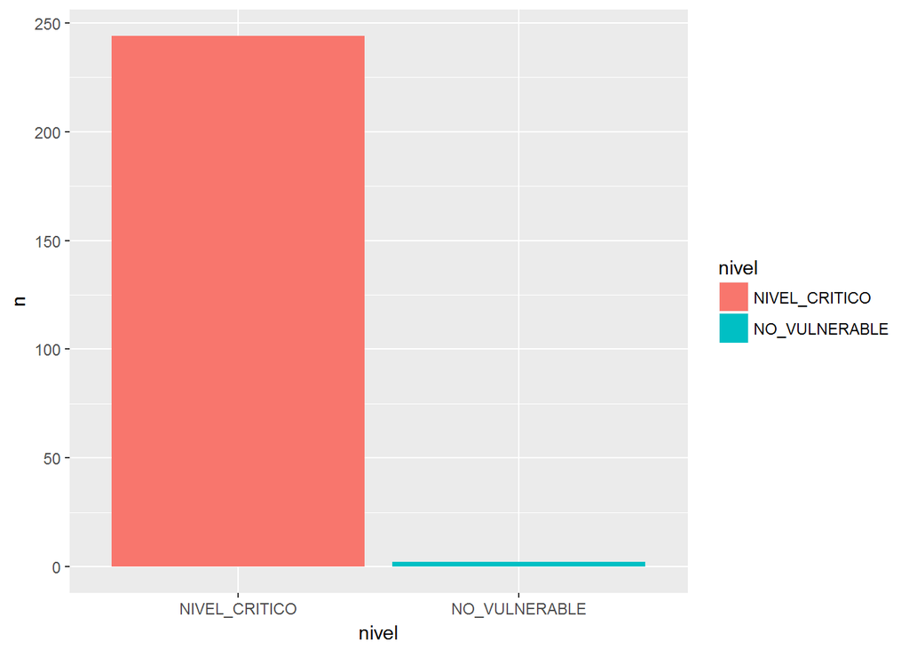

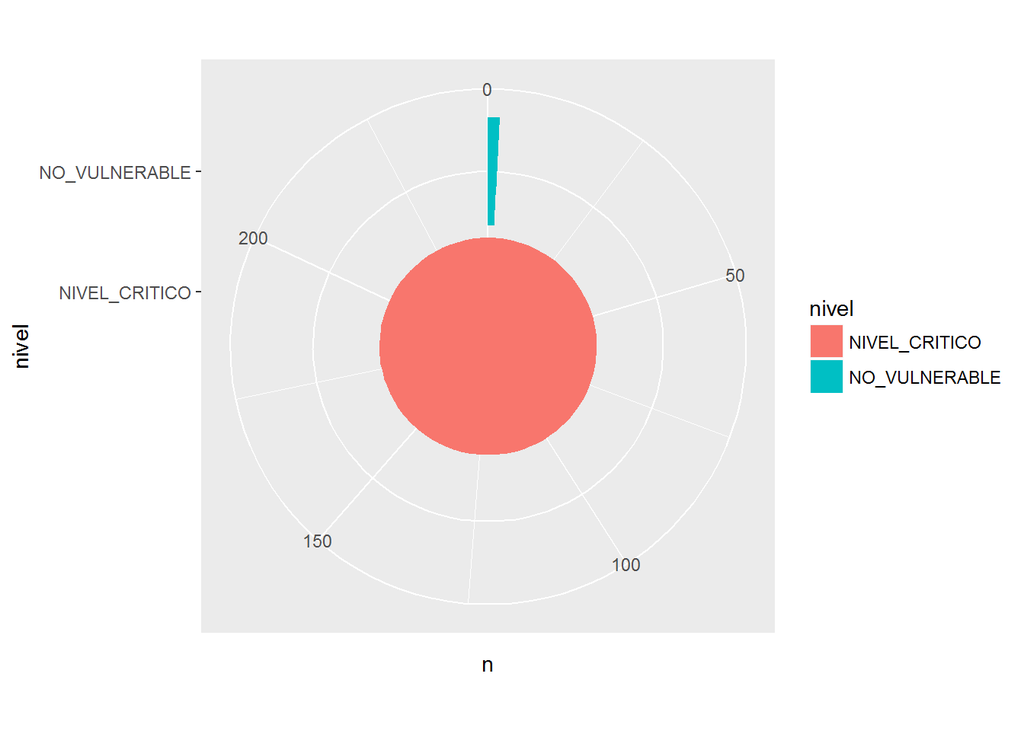

## ==================================================================================